# DataMining_FinalCode

```r
install.packages('caTools')
install.packages('caret')
install.packages('rpart.plot')
install.packages('rattle')
install.packages('ROCR')
install.packages('pROC')
install.packages('olsrr')
install.packages('e1071')
install.packages('Hmisc')
install.packages("survival")
install.packages('corrplot')
install.packages('kernlab')
install.packages("Survival")
```

```r
#clearing working environment
rm(list=ls())

library(caTools)
library(corrplot)
library(kernlab)
library(caTools)
library(caret) # Accuracy
library(ggplot2)
library(rpart)
library(rpart.plot)
library(rattle)
library(ROCR)
library(pROC)
library(olsrr)
library(e1071)
library(Hmisc)
#library(Survival)
```

## Using Local Dataset location

```r
#Using Local Dataset location
data <- read.csv(file="C:/Users/HP/Desktop/DataMining_Project/OnlineNewsPopularity/OnlineNewsPopularity.csv", header=TRUE, sep=",")
```

## Summary before cleaning

```r
#summary before cleaning
summary(data)
```

```
                                                             url
 http://mashable.com/2013/01/07/amazon-instant-video-browser/  :    1
 http://mashable.com/2013/01/07/ap-samsung-sponsored-tweets/   :    1
 http://mashable.com/2013/01/07/apple-40-billion-app-downloads/:    1
 http://mashable.com/2013/01/07/astronaut-notre-dame-bcs/      :    1
 http://mashable.com/2013/01/07/att-u-verse-apps/              :    1
 http://mashable.com/2013/01/07/beewi-smart-toys/              :    1
 (Other)                                                       :39638
   timedelta     n_tokens_title n_tokens_content n_unique_tokens
 Min.   :  8.0   Min.   : 2.0   Min.   :   0.0   Min.   :  0.0000
 1st Qu.:164.0   1st Qu.: 9.0   1st Qu.: 246.0   1st Qu.:  0.4709
 Median :339.0   Median :10.0   Median : 409.0   Median :  0.5392
 Mean   :354.5   Mean   :10.4   Mean   : 546.5   Mean   :  0.5482
 3rd Qu.:542.0   3rd Qu.:12.0   3rd Qu.: 716.0   3rd Qu.:  0.6087
 Max.   :731.0   Max.   :23.0   Max.   :8474.0   Max.   :701.0000

 n_non_stop_words    n_non_stop_unique_tokens   num_hrefs
 Min.   :   0.0000   Min.   :  0.0000         Min.   :  0.00
 1st Qu.:   1.0000   1st Qu.:  0.6257         1st Qu.:  4.00
 Median :   1.0000   Median :  0.6905         Median :  8.00
 Mean   :   0.9965   Mean   :  0.6892         Mean   : 10.88
 3rd Qu.:   1.0000   3rd Qu.:  0.7546         3rd Qu.: 14.00
 Max.   :1042.0000   Max.   :650.0000         Max.   :304.00

 num_self_hrefs       num_imgs         num_videos    average_token_length
 Min.   :  0.000   Min.   :  0.000   Min.   : 0.00   Min.   :0.000
 1st Qu.:  1.000   1st Qu.:  1.000   1st Qu.: 0.00   1st Qu.:4.478
 Median :  3.000   Median :  1.000   Median : 0.00   Median :4.664
 Mean   :  3.294   Mean   :  4.544   Mean   : 1.25   Mean   :4.548
 3rd Qu.:  4.000   3rd Qu.:  4.000   3rd Qu.: 1.00   3rd Qu.:4.855
 Max.   :116.000   Max.   :128.000   Max.   :91.00   Max.   :8.042

  num_keywords    data_channel_is_lifestyle data_channel_is_entertainment
 Min.   : 1.000   Min.   :0.00000           Min.   :0.000
 1st Qu.: 6.000   1st Qu.:0.00000           1st Qu.:0.000
 Median : 7.000   Median :0.00000           Median :0.000
 Mean   : 7.224   Mean   :0.05295           Mean   :0.178
 3rd Qu.: 9.000   3rd Qu.:0.00000           3rd Qu.:0.000
 Max.   :10.000   Max.   :1.00000           Max.   :1.000

```

[output cut: 96 more lines]

```
 title_subjectivity title_sentiment_polarity abs_title_subjectivity
 Min.   :0.0000     Min.   :-1.00000         Min.   :0.0000
 1st Qu.:0.0000     1st Qu.: 0.00000         1st Qu.:0.1667
 Median :0.1500     Median : 0.00000         Median :0.5000
 Mean   :0.2824     Mean   : 0.07143         Mean   :0.3418
 3rd Qu.:0.5000     3rd Qu.: 0.15000         3rd Qu.:0.5000
 Max.   :1.0000     Max.   : 1.00000         Max.   :0.5000

 abs_title_sentiment_polarity     shares
 Min.   :0.0000               Min.   :     1
 1st Qu.:0.0000               1st Qu.:   946
 Median :0.0000               Median :  1400
 Mean   :0.1561               Mean   :  3395
 3rd Qu.:0.2500               3rd Qu.:  2800
 Max.   :1.0000               Max.   :843300
```

```r
dim(data)
```

# Exploratory Data Analysis & Cleaning Data:

## Check for any missing values:

```r
# Exploratory Data Analysis & Cleaning Data:
# Check for any missing values:
sum(is.na(data))
```

0

## Removing outlier

```r
#Removing outlier
data=data[!data$n_non_stop_words==1042,]
summary(data)
```

```
                                                             url
 http://mashable.com/2013/01/07/amazon-instant-video-browser/  :    1
 http://mashable.com/2013/01/07/ap-samsung-sponsored-tweets/   :    1
 http://mashable.com/2013/01/07/apple-40-billion-app-downloads/:    1
 http://mashable.com/2013/01/07/astronaut-notre-dame-bcs/      :    1
 http://mashable.com/2013/01/07/att-u-verse-apps/              :    1
 http://mashable.com/2013/01/07/beewi-smart-toys/              :    1
 (Other)                                                       :39637
   timedelta     n_tokens_title n_tokens_content n_unique_tokens
 Min.   :  8.0   Min.   : 2.0   Min.   :   0.0   Min.   :0.0000
 1st Qu.:164.0   1st Qu.: 9.0   1st Qu.: 246.0   1st Qu.:0.4709
 Median :339.0   Median :10.0   Median : 409.0   Median :0.5392
 Mean   :354.5   Mean   :10.4   Mean   : 546.5   Mean   :0.5305
 3rd Qu.:542.0   3rd Qu.:12.0   3rd Qu.: 716.0   3rd Qu.:0.6087
 Max.   :731.0   Max.   :23.0   Max.   :8474.0   Max.   :1.0000

 n_non_stop_words n_non_stop_unique_tokens   num_hrefs      num_self_hrefs
 Min.   :0.0000   Min.   :0.0000           Min.   :  0.00   Min.   :  0.000
 1st Qu.:1.0000   1st Qu.:0.6257           1st Qu.:  4.00   1st Qu.:  1.000
 Median :1.0000   Median :0.6905           Median :  8.00   Median :  3.000
 Mean   :0.9702   Mean   :0.6728           Mean   : 10.88   Mean   :  3.293
 3rd Qu.:1.0000   3rd Qu.:0.7546           3rd Qu.: 14.00   3rd Qu.:  4.000
 Max.   :1.0000   Max.   :1.0000           Max.   :304.00   Max.   :116.000

    num_imgs         num_videos    average_token_length  num_keywords
 Min.   :  0.000   Min.   : 0.00   Min.   :0.000        Min.   : 1.000
 1st Qu.:  1.000   1st Qu.: 0.00   1st Qu.:4.478        1st Qu.: 6.000
 Median :  1.000   Median : 0.00   Median :4.664        Median : 7.000
 Mean   :  4.543   Mean   : 1.25   Mean   :4.548        Mean   : 7.224
 3rd Qu.:  4.000   3rd Qu.: 1.00   3rd Qu.:4.855        3rd Qu.: 9.000
 Max.   :128.000   Max.   :91.00   Max.   :8.042        Max.   :10.000

 data_channel_is_lifestyle data_channel_is_entertainment data_channel_is_bus
 Min.   :0.00000           Min.   :0.000                 Min.   :0.0000
 1st Qu.:0.00000           1st Qu.:0.000                 1st Qu.:0.0000
 Median :0.00000           Median :0.000                 Median :0.0000
 Mean   :0.05295           Mean   :0.178                 Mean   :0.1579
 3rd Qu.:0.00000           3rd Qu.:0.000                 3rd Qu.:0.0000
 Max.   :1.00000           Max.   :1.000                 Max.   :1.0000

```

[output cut: 96 more lines]

```
 title_subjectivity title_sentiment_polarity abs_title_subjectivity
 Min.   :0.0000     Min.   :-1.00000         Min.   :0.0000
 1st Qu.:0.0000     1st Qu.: 0.00000         1st Qu.:0.1667
 Median :0.1500     Median : 0.00000         Median :0.5000
 Mean   :0.2824     Mean   : 0.07143         Mean   :0.3419
 3rd Qu.:0.5000     3rd Qu.: 0.15000         3rd Qu.:0.5000
 Max.   :1.0000     Max.   : 1.00000         Max.   :0.5000

 abs_title_sentiment_polarity     shares
 Min.   :0.0000               Min.   :     1
 1st Qu.:0.0000               1st Qu.:   946
 Median :0.0000               Median :  1400
 Mean   :0.1561               Mean   :  3395
 3rd Qu.:0.2500               3rd Qu.:  2800
 Max.   :1.0000               Max.   :843300
```

## Removing non predictive variables

```r
#Removing non predictive variables
data <- subset( data, select = -c(url ,is_weekend ) )
```

```r
dim(data)
```

1. 39643

2. 59

## Combining Plots for EDA for visual analysis

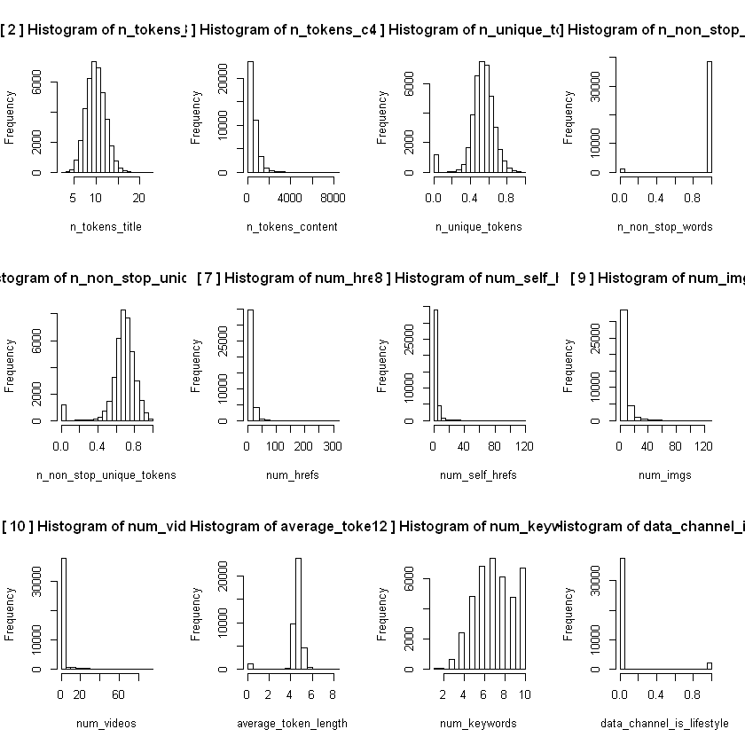

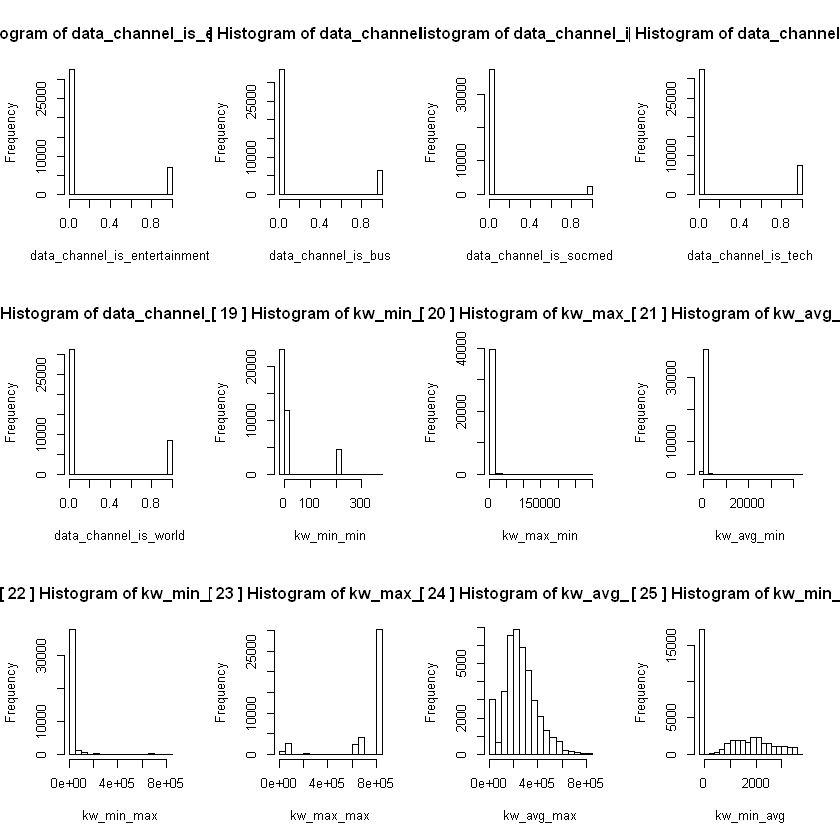

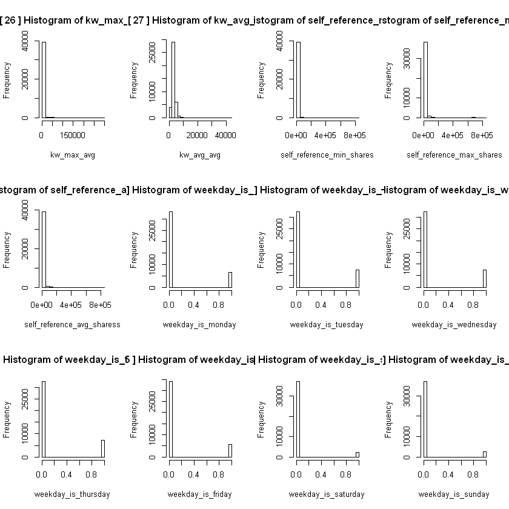

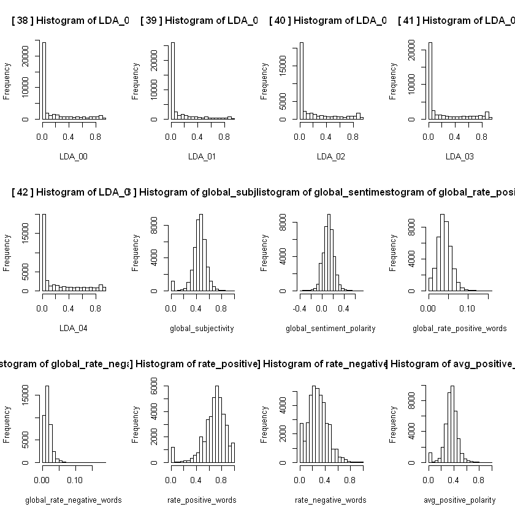

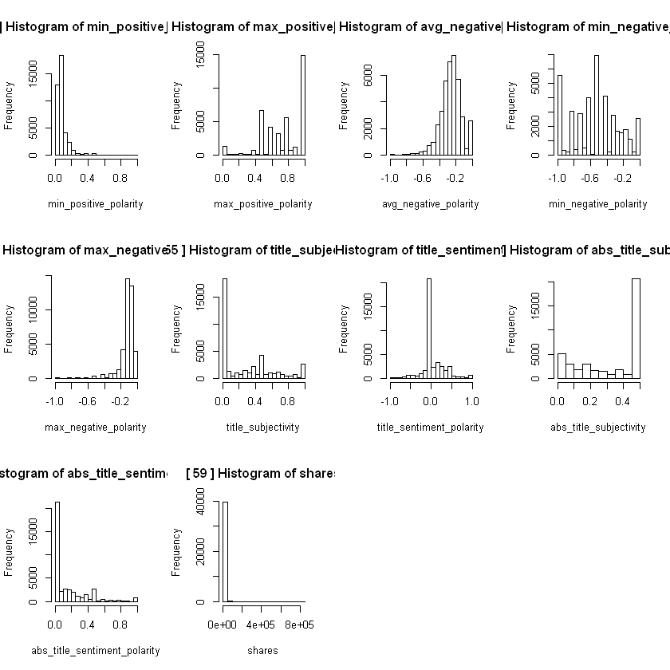

```r
#Combining Plots for EDA for visual analysis
par(mfrow=c(3,4))
for(i in 2:length(data)){hist(data[,i],
                              xlab=names(data)[i] , main = paste("[" , i , "]" ,
                                                                 "Histogram of", names(data)[i])  )}
```

```r
#read in data
raw<-read.csv("OnlineNewsPopularity.csv")
dim(raw)
```

1. 39644

2. 61

```r
head(raw)
```

| url | timedelta | n_tokens_title | n_tokens_content | n_unique_tokens | n_non_stop_words | n_non_stop_unique_tokens | num_hrefs | num_self_hrefs | num_imgs | ... | min_positive_polarity | max_positive_polarity | avg_negative_polarity | min_negative_polarity | max_negative_polarity | title_subjectivity | title_sentiment_polarity | abs_title_subjectivity | abs_title_sentiment_polarity | shares |
| --- | --- | --- | --- | --- | --- | --- | --- | --- | --- | --- | --- | --- | --- | --- | --- | --- | --- | --- | --- | --- |
| http://mashable.com/2013/01/07/amazon-instant-video-browser/ | 731 | 12 | 219 | 0.6635945 | 1 | 0.8153846 | 4 | 2 | 1 | ... | 0.10000000 | 0.7 | -0.3500000 | -0.600 | -0.2000000 | 0.5000000 | -0.1875000 | 0.00000000 | 0.1875000 | 593 |
| http://mashable.com/2013/01/07/ap-samsung-sponsored-tweets/ | 731 | 9 | 255 | 0.6047431 | 1 | 0.7919463 | 3 | 1 | 1 | ... | 0.03333333 | 0.7 | -0.1187500 | -0.125 | -0.1000000 | 0.0000000 | 0.0000000 | 0.50000000 | 0.0000000 | 711 |
| http://mashable.com/2013/01/07/apple-40-billion-app-downloads/ | 731 | 9 | 211 | 0.5751295 | 1 | 0.6638655 | 3 | 1 | 1 | ... | 0.10000000 | 1.0 | -0.4666667 | -0.800 | -0.1333333 | 0.0000000 | 0.0000000 | 0.50000000 | 0.0000000 | 1500 |
| http://mashable.com/2013/01/07/astronaut-notre-dame-bcs/ | 731 | 9 | 531 | 0.5037879 | 1 | 0.6656347 | 9 | 0 | 1 | ... | 0.13636364 | 0.8 | -0.3696970 | -0.600 | -0.1666667 | 0.0000000 | 0.0000000 | 0.50000000 | 0.0000000 | 1200 |
| http://mashable.com/2013/01/07/att-u-verse-apps/ | 731 | 13 | 1072 | 0.4156456 | 1 | 0.5408895 | 19 | 19 | 20 | ... | 0.03333333 | 1.0 | -0.2201923 | -0.500 | -0.0500000 | 0.4545455 | 0.1363636 | 0.04545455 | 0.1363636 | 505 |
| http://mashable.com/2013/01/07/beewi-smart-toys/ | 731 | 10 | 370 | 0.5598886 | 1 | 0.6981982 | 2 | 2 | 0 | ... | 0.13636364 | 0.6 | -0.1950000 | -0.400 | -0.1000000 | 0.6428571 | 0.2142857 | 0.14285714 | 0.2142857 | 855 |

```r
#sapply(raw, class)
raw[,61] <- as.numeric(raw[,61])
raw <- raw[,-1]
```

```r
suppressWarnings(library(ggplot2))
suppressWarnings(library(reshape2))
#suppressWarnings(library(DAAG))
```

### outlier in var “n_unique_tokens”, “n_non_stop_words”, and “n_non_stop_unique_tokens”, which might be due to typing error. We will remove that observation.

```r
raw <- raw[raw[,4]<1,]
```

### Missing values are very troubling in this data set because they are coded as 0. So you have to judge if the 0 are missing or real data. By check the distributions, we found around 3000 observations with missing values in 9 different variables. We will remove all cases with missing values.

```r
for(i in c(11,20,44,45,46,48,49,50,53))raw <- raw[raw[,i]!=0,]
```

### Skewed data. Lots of the variables are heavily right skewed, including the response “shares”. So we will transform them to reduce the skewness. For those variables with all values bigger than 0, we use log, and other variable with 0, we use square root to transform them.

```r
for(i in c(3,7,8,9,10,22,26:30,39:43,47, 60)){
  if(!sum(raw[,i]==0)){raw[,i] <- log(raw[,i]); names(raw)[i] <- paste("log_",names(raw)[i], sep="")}
  else{raw[,i] <- sqrt(raw[,i]); names(raw)[i] <- paste("sqrt_",names(raw)[i], sep="")}
}
```

### 19th, 21st, 23rd, 25th Variables contains negative values that cannot be explained by information available, so they will be removed

```r
raw <- raw[, -c(19,21,23,25)]
```

## 2. Does subjects and publishing days of news matters?

### a. Subjects matters?

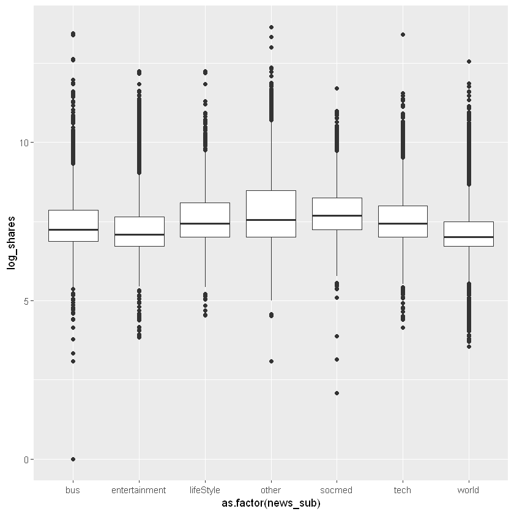

```r
raw$news_sub <- rep("other", nrow(raw))
raw$news_sub[raw$data_channel_is_lifestyle==1] <- "lifeStyle"
raw$news_sub[raw$data_channel_is_entertainment==1] <- "entertainment"
raw$news_sub[raw$data_channel_is_bus==1] <- "bus"
raw$news_sub[raw$data_channel_is_socmed==1] <- "socmed"
raw$news_sub[raw$data_channel_is_tech==1] <- "tech"
raw$news_sub[raw$data_channel_is_world==1] <- "world"
# plot
p1 <- ggplot(data=raw, aes(as.factor(news_sub), log_shares))
p1 + geom_boxplot()
```

### b. Publishing Days might or might not affect shares, let's look at it.

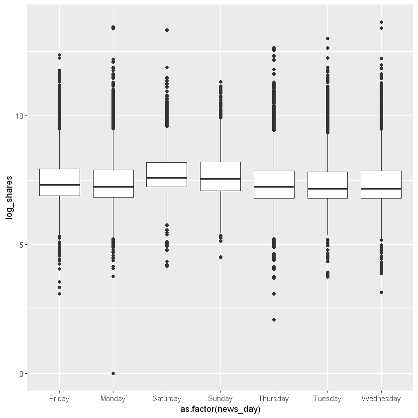

```r
raw$news_day <- rep("Sunday", nrow(raw))
raw$news_day[raw$weekday_is_monday==1] <- "Monday"
raw$news_day[raw$weekday_is_tuesday==1] <- "Tuesday"
raw$news_day[raw$weekday_is_wednesday==1] <- "Wednesday"
raw$news_day[raw$weekday_is_thursday==1] <- "Thursday"
raw$news_day[raw$weekday_is_friday==1] <- "Friday"
raw$news_day[raw$weekday_is_saturday==1] <- "Saturday"
#Check
p1 <- ggplot(data=raw, aes(as.factor(news_day), log_shares))
p1 + geom_boxplot()
```

### Publishing day didn't show much influence on shares neither. So I will get rid of all the indicators but leave "is_weekend" because I do see some difference bewtween weekdays and weekend data.

```r
raw2 <- raw[,-c(13:18, 27:33, 57,58)]
```

## 3. PCA analysis

### PCA analysis can tell us where the variance of our independent variables are from? How they form the shape of our data variance.

```r
x <- as.matrix(scale(raw2[,-43]))
dim(x)
```

1. 36274

2. 42

```r
dim(x)
```

1. 36274

2. 42

```r
corx <- cor(x)
dim(corx)
```

1. 42

2. 42

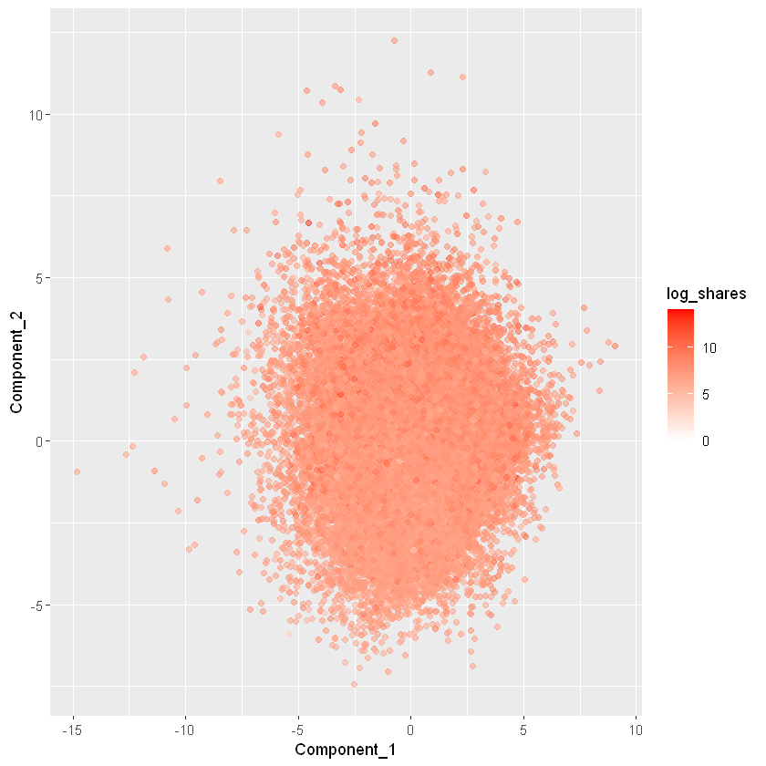

```r
evd<-svd(corx)
w <- x %*% evd$u
pca2 <- as.data.frame(cbind(w[,1:4], raw2$log_shares))
names(pca2) <- c("Component_1", "Component_2", "Component_3", "Component_4", "log_shares")
#Map share on first two components
pcaplot <- ggplot(aes(Component_1, Component_2, colour=log_shares), data=pca2)
pcaplot + geom_point(alpha = 0.5) + scale_colour_gradient(limits=c(0, 14), low="white", high="red")
```

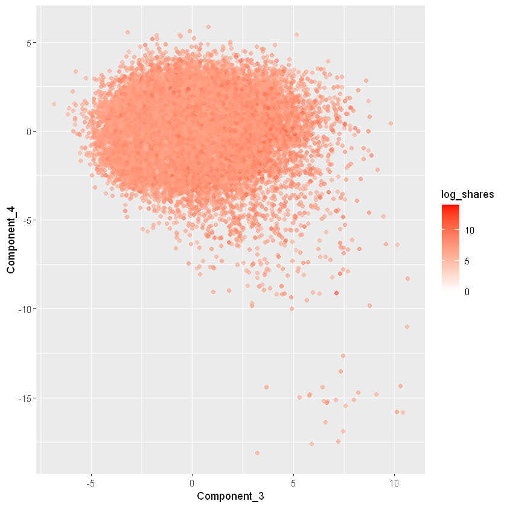

```r
#Map share on 3rd and 4th components
pcaplot <- ggplot(aes(Component_3, Component_4, colour=log_shares), data=pca2)
pcaplot + geom_point(alpha = 0.5) + scale_colour_gradient(limits=c(0, 14), low="white", high="red")
```

### Conclusion, the variance of share number is not aligned with the first 4 major components of variance from independent variables.In other words, most of the infomation from our independent variables might not be related to our dependent variable. So there are too much non-relevant information we should get rid of.

## 4. Does all potential predictors are independent to each other and relevant to our dependent variable?

### I will use heatmap to check correlation matrix of the 43 left columns

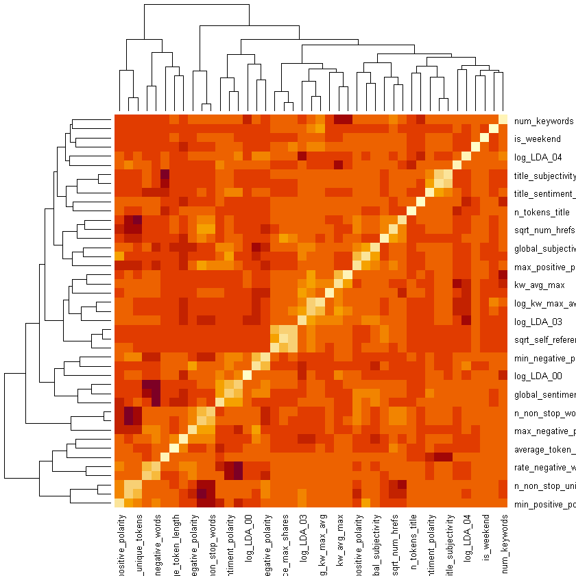

```r
corm<-1-cor(raw2)
heatmap(corm)
```

### Let's further loot at the correlations of different variables with our dependenet variables.

```
   Min. 1st Qu.  Median    Mean 3rd Qu.    Max.
 0.7462  0.9317  0.9489  0.9540  1.0057  1.1527
```

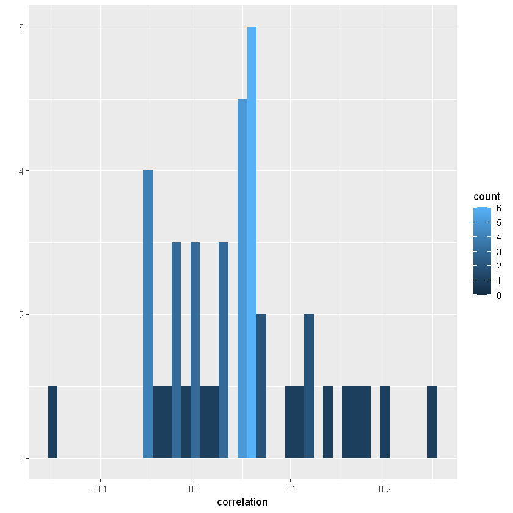

```r
summary(corm[43,-43])
qplot(1-corm[43,-43], binwidth=0.01, fill=..count.., geom="histogram", xlab="correlation")
```

### Generally all the predictors have pretty low correlations with our log(shares). We have some variables have nearly 0 correlations with share numbers. Considering most variables relative low correlations, we will not exclude any variables because of low correlation.

### From the heatmap above, we can tell there indeed are some groups of variables which are pretty close to each other. Let's build the tree and cut it to get groups!

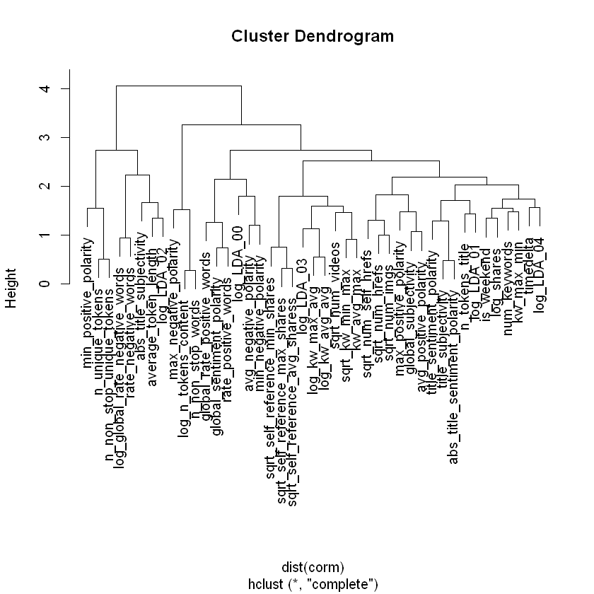

```r
hc <- hclust(dist(corm))
par(mfrow=c(1,1))
plot(hc)
```

## Converting categorical values from numeric to factor - Weekdays

```r
#Converting categorical values from numeric to factor - Weekdays
for (i in 31:37){
  data[,i] <- factor(data[,i])
}
```

## Converting categorical values from numeric to factor - News subjects

```r
#Converting categorical values from numeric to factor - News subjects
for (i in 13:18){
  data[,i] <- factor(data[,i])
}
```

## check classes of data after transformation

```r
sapply(data, class)
```

**timedelta**

'numeric'

**n_tokens_title**

'numeric'

**n_tokens_content**

'numeric'

**n_unique_tokens**

'numeric'

**n_non_stop_words**

'numeric'

**n_non_stop_unique_tokens**

'numeric'

**num_hrefs**

'numeric'

**num_self_hrefs**

'numeric'

**num_imgs**

'numeric'

**num_videos**

'numeric'

**average_token_length**

'numeric'

**num_keywords**

'numeric'

**data_channel_is_lifestyle**

'factor'

**data_channel_is_entertainment**

'factor'

**data_channel_is_bus**

'factor'

**data_channel_is_socmed**

'factor'

**data_channel_is_tech**

'factor'

**data_channel_is_world**

'factor'

**kw_min_min**

'numeric'

**kw_max_min**

'numeric'

**kw_avg_min**

'numeric'

**kw_min_max**

'numeric'

**kw_max_max**

'numeric'

**kw_avg_max**

'numeric'

**kw_min_avg**

'numeric'

**kw_max_avg**

'numeric'

**kw_avg_avg**

'numeric'

**self_reference_min_shares**

'numeric'

**self_reference_max_shares**

'numeric'

**self_reference_avg_sharess**

'numeric'

**weekday_is_monday**

'factor'

**weekday_is_tuesday**

'factor'

**weekday_is_wednesday**

'factor'

**weekday_is_thursday**

'factor'

**weekday_is_friday**

'factor'

**weekday_is_saturday**

'factor'

**weekday_is_sunday**

'factor'

**LDA_00**

'numeric'

**LDA_01**

'numeric'

**LDA_02**

'numeric'

**LDA_03**

'numeric'

**LDA_04**

'numeric'

**global_subjectivity**

'numeric'

**global_sentiment_polarity**

'numeric'

**global_rate_positive_words**

'numeric'

**global_rate_negative_words**

'numeric'

**rate_positive_words**

'numeric'

**rate_negative_words**

'numeric'

**avg_positive_polarity**

'numeric'

**min_positive_polarity**

'numeric'

**max_positive_polarity**

'numeric'

**avg_negative_polarity**

'numeric'

**min_negative_polarity**

'numeric'

**max_negative_polarity**

'numeric'

**title_subjectivity**

'numeric'

**title_sentiment_polarity**

'numeric'

**abs_title_subjectivity**

'numeric'

**abs_title_sentiment_polarity**

'numeric'

**shares**

'integer'

## Checking importance of news subjects(categorical) on shares

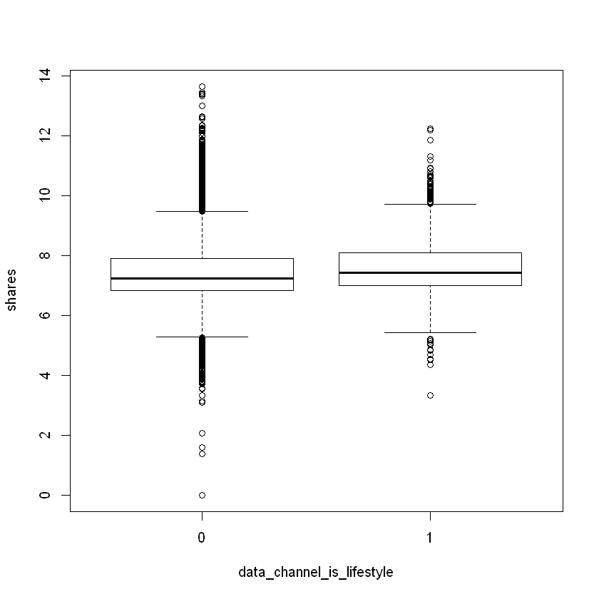

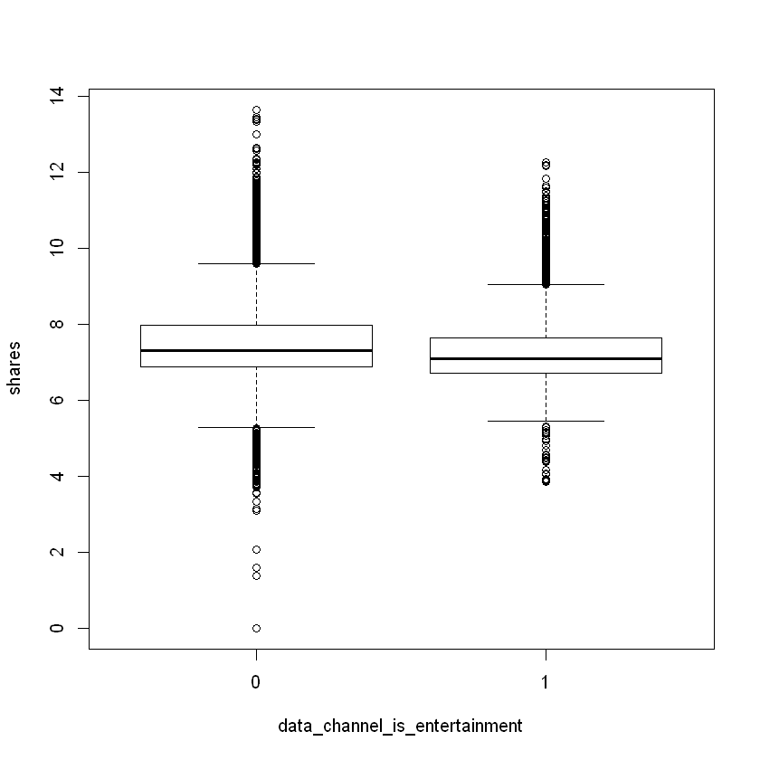

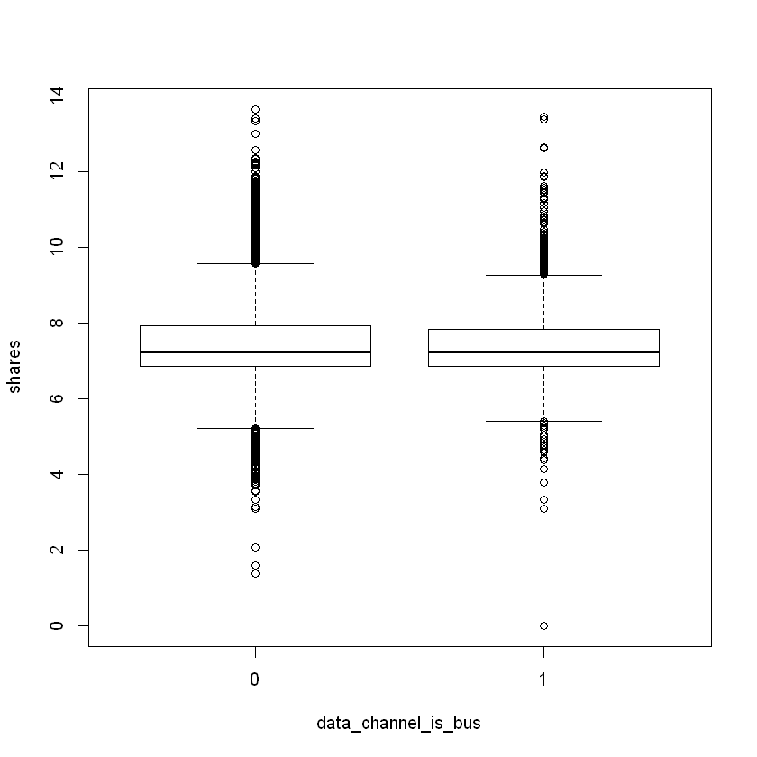

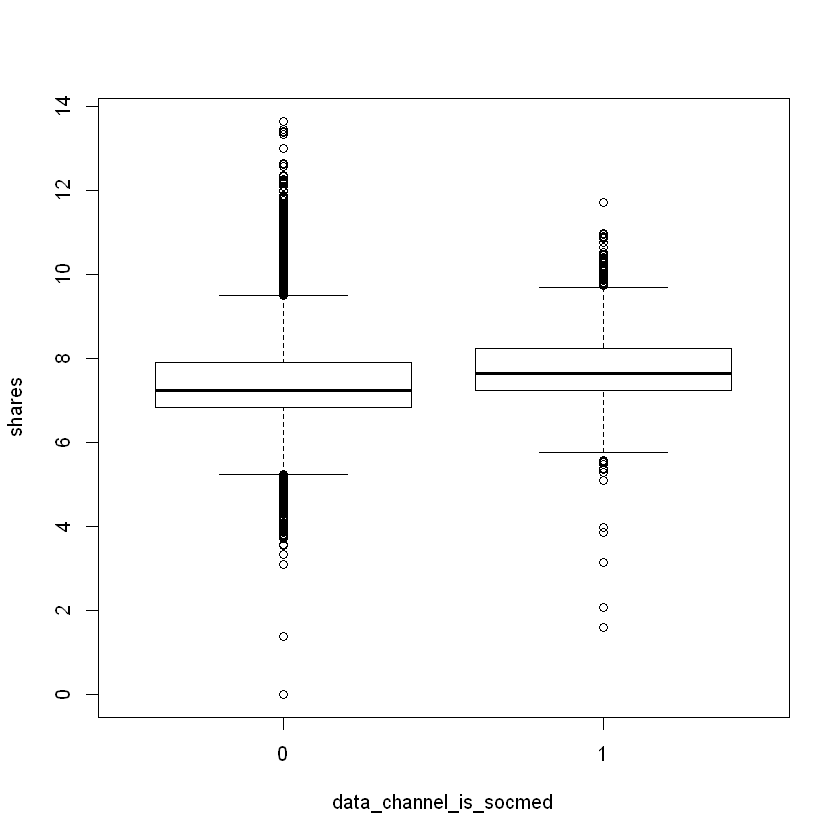

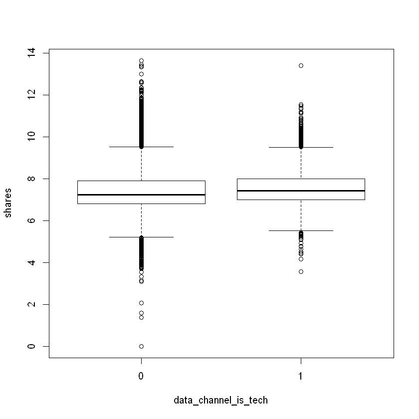

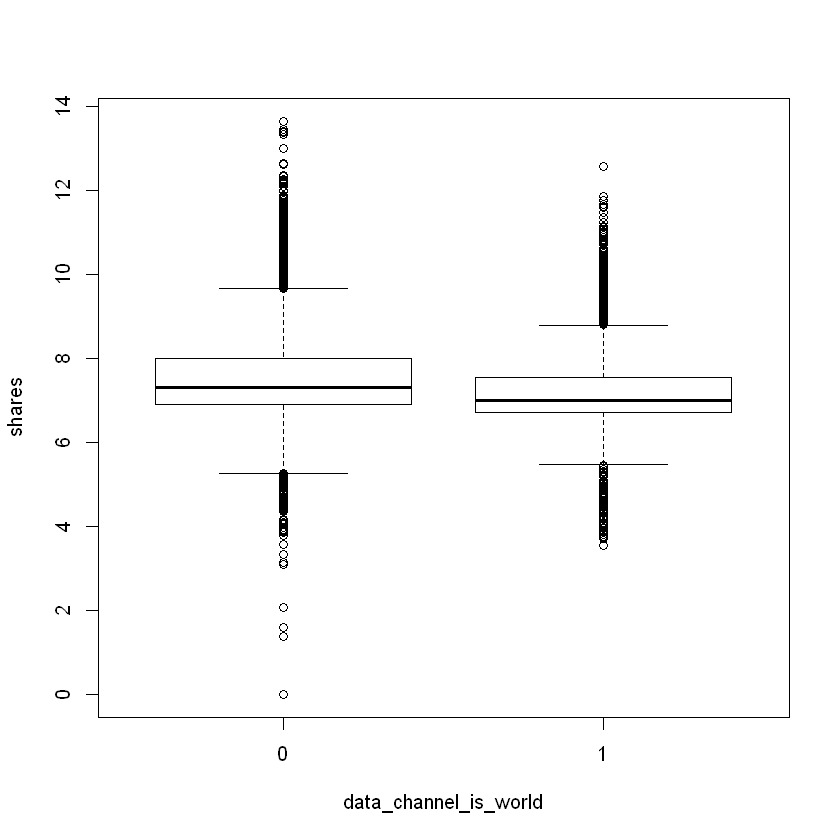

```r
#Checking importance of news subjects(categorical) on shares
for (i in 13:18){

  boxplot(log(data$shares) ~ (data[,i]), xlab=names(data)[i] , ylab="shares")
}
```

## Checking importance of weekdays on news shares

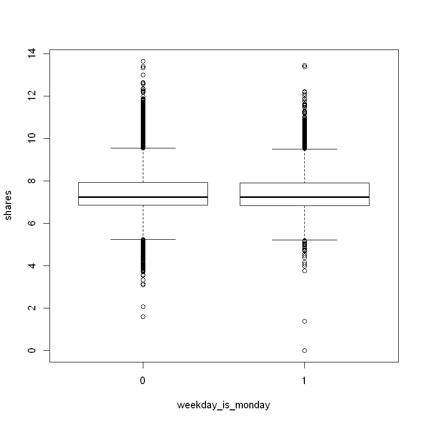

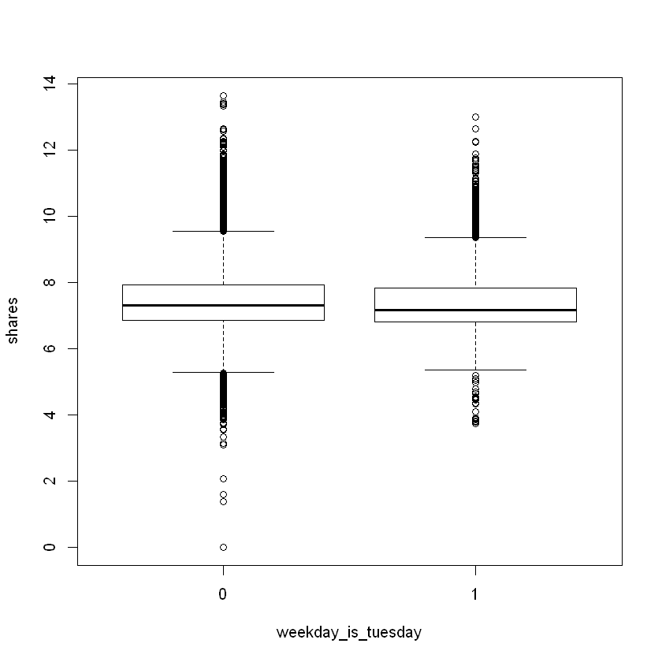

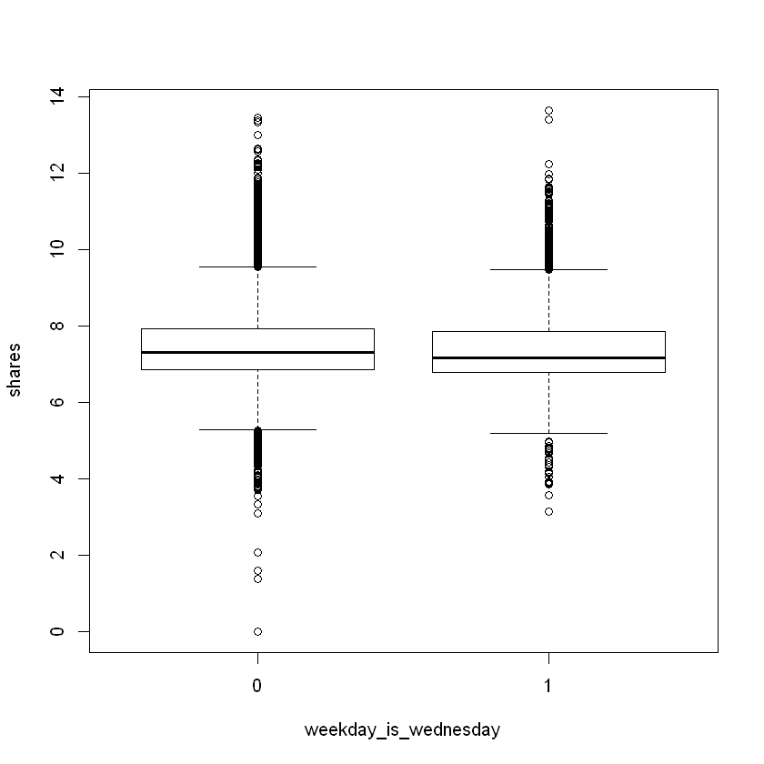

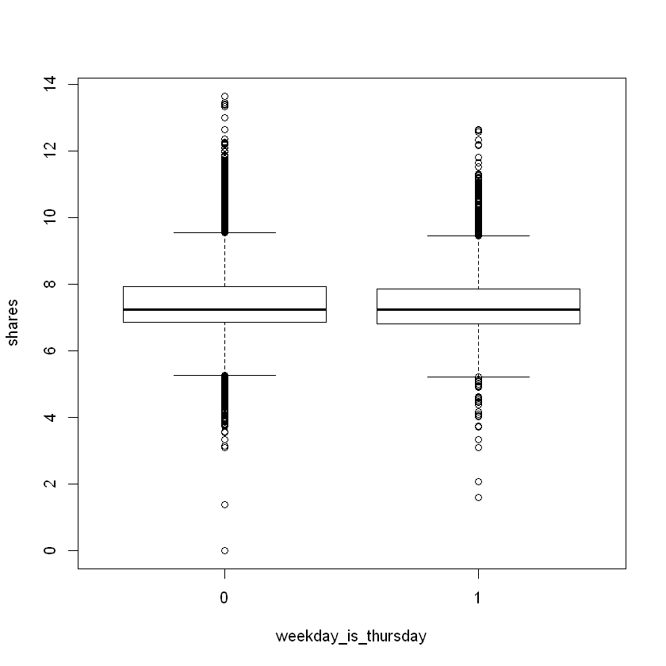

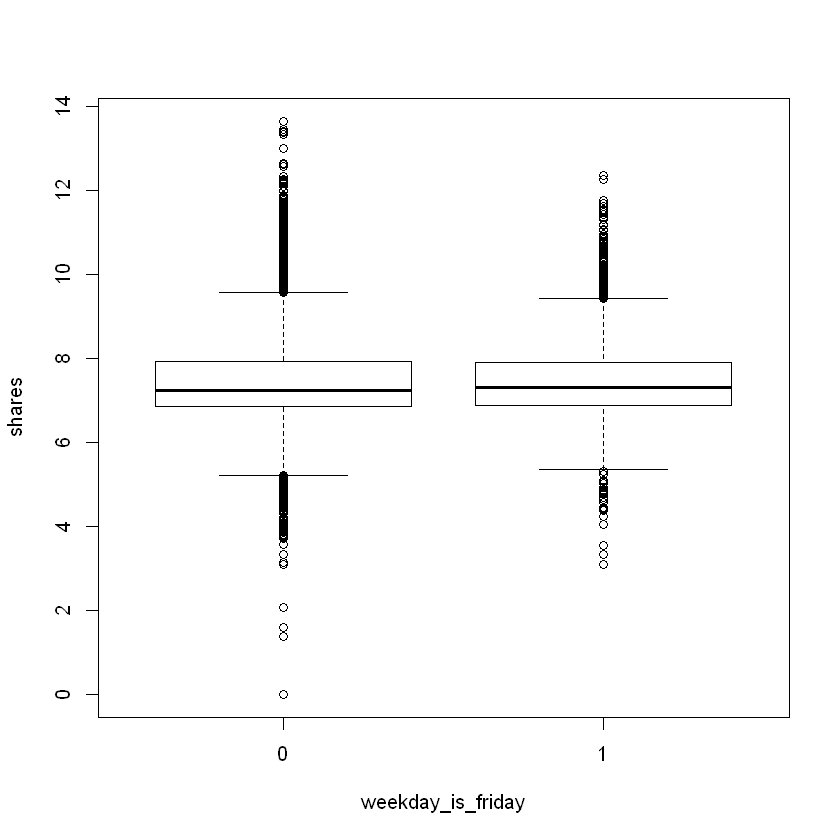

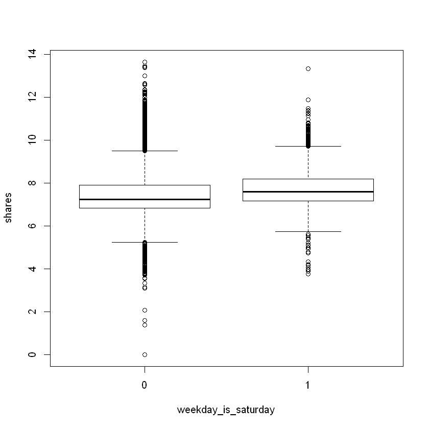

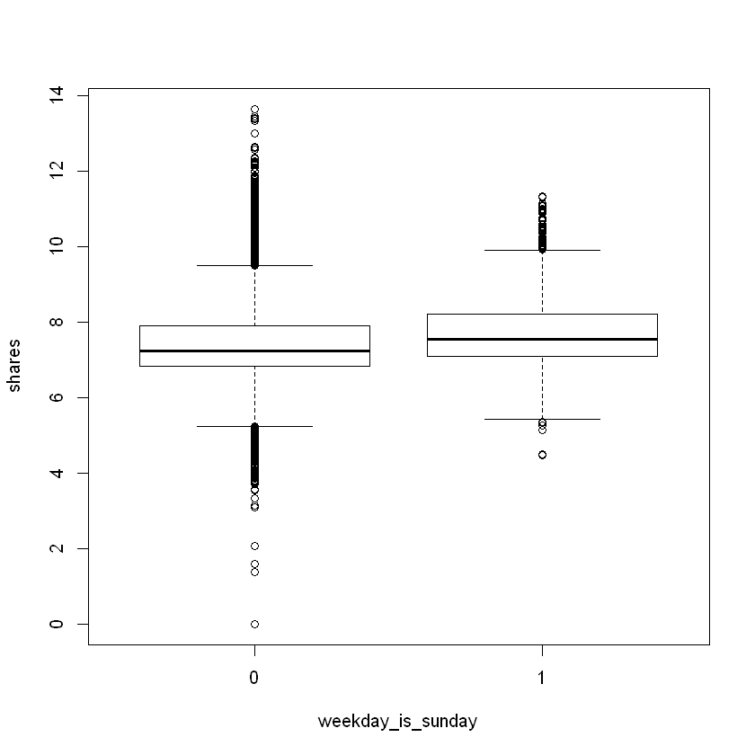

```r
#Checking importance of weekdays on news shares
for (i in 31:37){

  boxplot(log(data$shares) ~ (data[,i]), xlab=names(data)[i] , ylab="shares")
}
```

# Sampling the dataset into training data and test data:

```r
# Sampling the dataset into training data and test data:

splitdata<- sample.split(data,SplitRatio = 0.7)
train_data <- subset(data, splitdata == TRUE)
test_data <- subset(data, splitdata == FALSE)
```

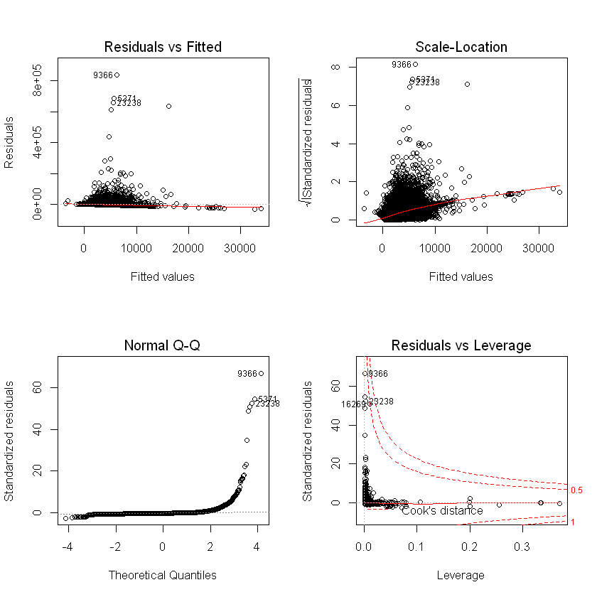

```r
#Using Linear Model

fit_lm <- lm(shares ~ ., data = train_data)
layout(matrix(1:4, 2, 2))
plot(fit_lm)
```

```r
summary(fit_lm)
```

```
Call:
lm(formula = shares ~ ., data = train_data)

Residuals:
   Min     1Q Median     3Q    Max
-32000  -2335  -1229    -52 837005

Coefficients: (2 not defined because of singularities)
                                 Estimate Std. Error t value Pr(>|t|)
(Intercept)                    -1.705e+03  1.250e+03  -1.365 0.172409
timedelta                       1.588e+00  5.160e-01   3.078 0.002086 **
n_tokens_title                  1.364e+02  3.805e+01   3.584 0.000339 ***
n_tokens_content                6.141e-01  3.005e-01   2.043 0.041019 *
n_unique_tokens                 4.138e+03  2.545e+03   1.626 0.103881
n_non_stop_words               -6.858e+02  7.476e+03  -0.092 0.926911
n_non_stop_unique_tokens       -2.242e+03  2.149e+03  -1.044 0.296718
num_hrefs                       3.372e+01  8.694e+00   3.879 0.000105 ***
num_self_hrefs                 -6.966e+01  2.327e+01  -2.994 0.002755 **
num_imgs                        6.587e+00  1.176e+01   0.560 0.575309
num_videos                      5.230e+00  2.033e+01   0.257 0.796985
average_token_length           -6.835e+02  3.181e+02  -2.149 0.031669 *
num_keywords                    8.627e+01  4.872e+01   1.771 0.076618 .
data_channel_is_lifestyle1     -9.075e+02  5.215e+02  -1.740 0.081857 .
data_channel_is_entertainment1 -9.718e+02  3.357e+02  -2.895 0.003797 **
data_channel_is_bus1           -7.308e+02  5.009e+02  -1.459 0.144593
data_channel_is_socmed1        -5.619e+02  4.865e+02  -1.155 0.248094
data_channel_is_tech1          -2.318e+02  4.884e+02  -0.475 0.635003
data_channel_is_world1         -1.509e+02  4.955e+02  -0.304 0.760750
kw_min_min                      1.194e+00  2.137e+00   0.559 0.576414
kw_max_min                      1.103e-01  6.057e-02   1.821 0.068611 .
kw_avg_min                     -7.541e-01  3.712e-01  -2.031 0.042218 *
kw_min_max                     -2.152e-03  1.599e-03  -1.346 0.178332
kw_max_max                     -7.119e-04  7.750e-04  -0.919 0.358311
kw_avg_max                      2.918e-04  1.113e-03   0.262 0.793280
kw_min_avg                     -3.947e-01  9.983e-02  -3.954 7.72e-05 ***
kw_max_avg                     -2.138e-01  3.319e-02  -6.439 1.22e-10 ***
kw_avg_avg                      1.776e+00  1.902e-01   9.334  < 2e-16 ***
self_reference_min_shares       1.980e-02  9.736e-03   2.033 0.042012 *
self_reference_max_shares      -5.214e-03  5.380e-03  -0.969 0.332506
self_reference_avg_sharess      1.765e-02  1.356e-02   1.301 0.193250
```

[output cut: 19 more lines]

```
min_positive_polarity          -1.405e+03  1.512e+03  -0.929 0.352793
max_positive_polarity           3.205e+02  5.657e+02   0.567 0.571028
avg_negative_polarity          -2.727e+03  1.656e+03  -1.646 0.099760 .
min_negative_polarity           3.055e+02  6.021e+02   0.507 0.611932
max_negative_polarity           4.540e+02  1.382e+03   0.329 0.742521
title_subjectivity             -5.651e+02  3.619e+02  -1.561 0.118453
title_sentiment_polarity        1.492e+02  3.272e+02   0.456 0.648415
abs_title_subjectivity          3.451e+02  4.794e+02   0.720 0.471549
abs_title_sentiment_polarity    1.035e+03  5.183e+02   1.997 0.045829 *
---
Signif. codes:  0 '***' 0.001 '**' 0.01 '*' 0.05 '.' 0.1 ' ' 1

Residual standard error: 12570 on 27490 degrees of freedom
Multiple R-squared:  0.02124,	Adjusted R-squared:  0.01924
F-statistic: 10.65 on 56 and 27490 DF,  p-value: < 2.2e-16
```

```r
#Forward stepwise regression to select variables
#using stepwise regression
#Taking important variables


d2 <- subset( data, select = c(n_tokens_title,timedelta, kw_avg_avg, self_reference_min_shares,
                             kw_min_avg, num_hrefs, kw_max_max, avg_negative_polarity,
                             data_channel_is_entertainment, weekday_is_monday,
                             LDA_02, kw_min_max, average_token_length, global_subjectivity,
                             kw_max_min, global_rate_positive_words,
                             n_tokens_content, n_non_stop_unique_tokens,
                             min_positive_polarity, weekday_is_saturday,
                             data_channel_is_lifestyle, kw_avg_max,
                             kw_avg_min, title_sentiment_polarity,
                             num_self_hrefs, self_reference_max_shares,
                             n_tokens_title, LDA_01, kw_min_min, shares) )
summary(d2$shares)
dim(d2)
```

```
   Min. 1st Qu.  Median    Mean 3rd Qu.    Max.
      1     946    1400    3395    2800  843300
```

1. 39643

2. 30

```
Call:
lm(formula = shares ~ ., data = traindata)

Residuals:
   Min     1Q Median     3Q    Max
-36640  -2241  -1256   -111 685140

Coefficients: (1 not defined because of singularities)
                                 Estimate Std. Error t value Pr(>|t|)
(Intercept)                     3.145e+02  7.742e+02   0.406 0.684556
n_tokens_title                  5.998e+01  3.118e+01   1.924 0.054396 .
timedelta                       1.249e+00  4.220e-01   2.960 0.003076 **
kw_avg_avg                      7.846e-01  7.457e-02  10.522  < 2e-16 ***
self_reference_min_shares       3.093e-02  3.871e-03   7.992 1.38e-15 ***
kw_min_avg                     -4.461e-02  6.829e-02  -0.653 0.513633
num_hrefs                       3.377e+01  7.002e+00   4.823 1.42e-06 ***
kw_max_max                      3.033e-04  6.258e-04   0.485 0.627954
avg_negative_polarity          -2.454e+03  5.704e+02  -4.302 1.70e-05 ***
data_channel_is_entertainment1 -9.153e+02  2.121e+02  -4.316 1.60e-05 ***
weekday_is_monday1              5.154e+02  1.704e+02   3.025 0.002489 **
LDA_02                         -1.462e+03  2.686e+02  -5.444 5.26e-08 ***
kw_min_max                     -2.972e-03  1.267e-03  -2.345 0.019029 *
average_token_length           -5.361e+02  1.347e+02  -3.980 6.92e-05 ***
global_subjectivity             2.461e+03  8.223e+02   2.993 0.002764 **
kw_max_min                     -8.045e-02  4.951e-02  -1.625 0.104197
global_rate_positive_words     -1.328e+04  4.590e+03  -2.892 0.003827 **
n_tokens_content                4.815e-01  1.752e-01   2.749 0.005990 **
n_non_stop_unique_tokens        3.024e+02  7.282e+02   0.415 0.677944
min_positive_polarity          -8.332e+02  1.017e+03  -0.819 0.412684
weekday_is_saturday1            2.624e+02  2.665e+02   0.985 0.324788
data_channel_is_lifestyle1     -3.718e+02  2.957e+02  -1.257 0.208695
kw_avg_max                      8.956e-04  7.667e-04   1.168 0.242761
kw_avg_min                      6.052e-02  3.254e-01   0.186 0.852446
title_sentiment_polarity        6.014e+02  2.436e+02   2.468 0.013581 *
num_self_hrefs                 -6.329e+01  1.840e+01  -3.441 0.000581 ***
self_reference_max_shares       2.323e-03  1.737e-03   1.337 0.181284
n_tokens_title.1                       NA         NA      NA       NA
LDA_01                          1.512e+02  3.664e+02   0.413 0.679835
kw_min_min                      2.324e+00  1.777e+00   1.308 0.190865
---
Signif. codes:  0 '***' 0.001 '**' 0.01 '*' 0.05 '.' 0.1 ' ' 1

Residual standard error: 10520 on 27721 degrees of freedom
Multiple R-squared:  0.02312,	Adjusted R-squared:  0.02213
F-statistic: 23.43 on 28 and 27721 DF,  p-value: < 2.2e-16
```

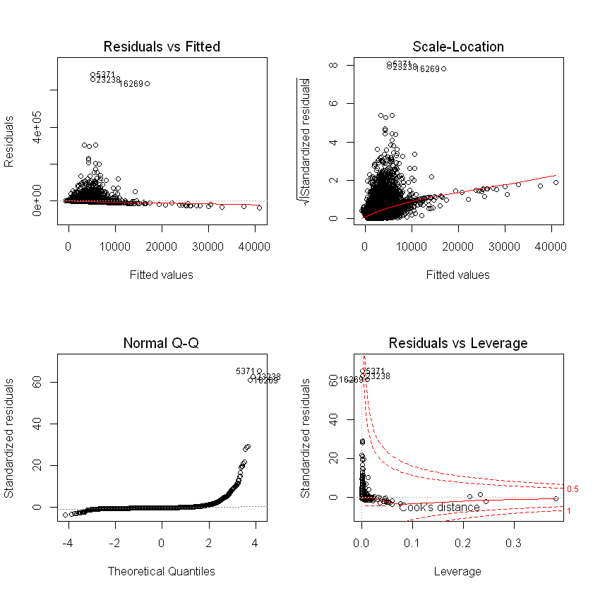

```r
# Sampling the dataset based on best variables

splitdata<- sample.split(d2,SplitRatio = 0.7)
traindata <- subset(d2, splitdata == TRUE)
testdata <- subset(d2, splitdata == FALSE)


# Now, we fit a model with all the variables;
fit_lmbest <- lm(shares ~ ., data = traindata)

summary(fit_lmbest)
layout(matrix(1:4, 2, 2))
plot(fit_lmbest)
```

```
   Min. 1st Qu.  Median    Mean 3rd Qu.    Max.
  0.000   6.852   7.244   7.475   7.937  13.645
```

```
Call:
lm(formula = shares ~ ., data = traindata)

Residuals:
   Min     1Q Median     3Q    Max
-36640  -2241  -1256   -111 685140

Coefficients: (1 not defined because of singularities)
                                 Estimate Std. Error t value Pr(>|t|)
(Intercept)                     3.145e+02  7.742e+02   0.406 0.684556
n_tokens_title                  5.998e+01  3.118e+01   1.924 0.054396 .
timedelta                       1.249e+00  4.220e-01   2.960 0.003076 **
kw_avg_avg                      7.846e-01  7.457e-02  10.522  < 2e-16 ***
self_reference_min_shares       3.093e-02  3.871e-03   7.992 1.38e-15 ***
kw_min_avg                     -4.461e-02  6.829e-02  -0.653 0.513633
num_hrefs                       3.377e+01  7.002e+00   4.823 1.42e-06 ***
kw_max_max                      3.033e-04  6.258e-04   0.485 0.627954
avg_negative_polarity          -2.454e+03  5.704e+02  -4.302 1.70e-05 ***
data_channel_is_entertainment1 -9.153e+02  2.121e+02  -4.316 1.60e-05 ***
weekday_is_monday1              5.154e+02  1.704e+02   3.025 0.002489 **
LDA_02                         -1.462e+03  2.686e+02  -5.444 5.26e-08 ***
kw_min_max                     -2.972e-03  1.267e-03  -2.345 0.019029 *
average_token_length           -5.361e+02  1.347e+02  -3.980 6.92e-05 ***
global_subjectivity             2.461e+03  8.223e+02   2.993 0.002764 **
kw_max_min                     -8.045e-02  4.951e-02  -1.625 0.104197
global_rate_positive_words     -1.328e+04  4.590e+03  -2.892 0.003827 **
n_tokens_content                4.815e-01  1.752e-01   2.749 0.005990 **
n_non_stop_unique_tokens        3.024e+02  7.282e+02   0.415 0.677944
min_positive_polarity          -8.332e+02  1.017e+03  -0.819 0.412684
weekday_is_saturday1            2.624e+02  2.665e+02   0.985 0.324788
data_channel_is_lifestyle1     -3.718e+02  2.957e+02  -1.257 0.208695
kw_avg_max                      8.956e-04  7.667e-04   1.168 0.242761
kw_avg_min                      6.052e-02  3.254e-01   0.186 0.852446
title_sentiment_polarity        6.014e+02  2.436e+02   2.468 0.013581 *
num_self_hrefs                 -6.329e+01  1.840e+01  -3.441 0.000581 ***
self_reference_max_shares       2.323e-03  1.737e-03   1.337 0.181284
n_tokens_title.1                       NA         NA      NA       NA
LDA_01                          1.512e+02  3.664e+02   0.413 0.679835
kw_min_min                      2.324e+00  1.777e+00   1.308 0.190865
---
Signif. codes:  0 '***' 0.001 '**' 0.01 '*' 0.05 '.' 0.1 ' ' 1

Residual standard error: 10520 on 27721 degrees of freedom
Multiple R-squared:  0.02312,	Adjusted R-squared:  0.02213
F-statistic: 23.43 on 28 and 27721 DF,  p-value: < 2.2e-16
```

0

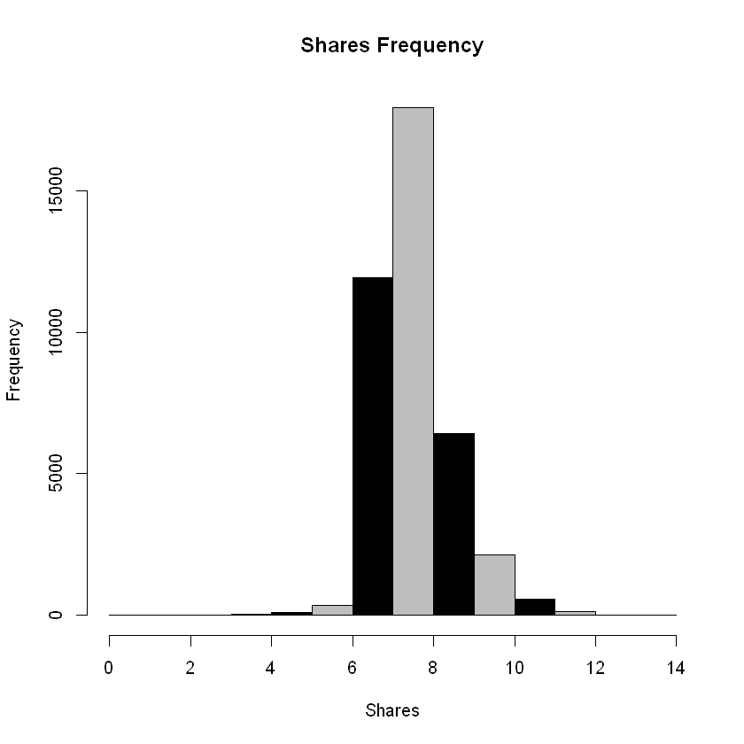

```r
#taking log shares to optimize model
####################################
d2$shares <- log(d2$shares)
summary(d2$shares)
fit_lmlog <- lm(shares ~ ., data = traindata)
summary(fit_lmlog)

sum(is.na(d2))

# Define articles with shares larger than 7.244 (median) as popular article
#######################################################################
d2$shares <- as.factor(ifelse(d2$shares > 7.244,1,0))
hist(log(data$shares), col = c("black", "gray")
     , xlab="Shares", main="Shares Frequency" )
```

```r
# Sampling the dataset based on best variables
splitdata<- sample.split(d2,SplitRatio = 0.7)
traindata <- subset(d2, splitdata == TRUE)
testdata <- subset(d2, splitdata == FALSE)

#Implementing Nayive bayes
nav.mod <- naiveBayes(shares~.,traindata)
#pred <- predict(nav.mod,testdata)
newsnb.pred<-predict(nav.mod,testdata,type="class" )
newsnb.prob<-predict(nav.mod,testdata,type="raw" )

confusionMatrix(newsnb.pred,testdata$shares)
```

```
Confusion Matrix and Statistics

          Reference
Prediction    0    1
         0 4456 3986
         1 1129 2322

               Accuracy : 0.5699
                 95% CI : (0.561, 0.5788)
    No Information Rate : 0.5304
    P-Value [Acc > NIR] : < 2.2e-16

                  Kappa : 0.1612

 Mcnemar's Test P-Value : < 2.2e-16

            Sensitivity : 0.7979
            Specificity : 0.3681
         Pos Pred Value : 0.5278
         Neg Pred Value : 0.6728
             Prevalence : 0.4696
         Detection Rate : 0.3747
   Detection Prevalence : 0.7098
      Balanced Accuracy : 0.5830

       'Positive' Class : 0
```

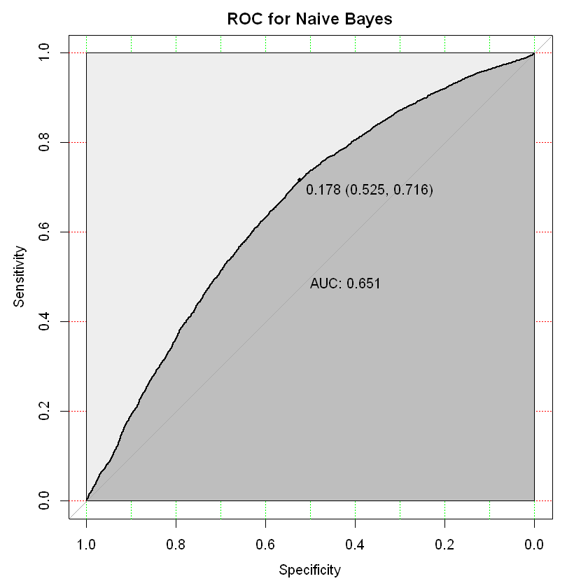

```r
#ROC Curve for Naive Bayes
newsnb.roc <- roc(testdata$shares,newsnb.prob[,2])
plot(newsnb.roc, print.auc=TRUE, auc.polygon=TRUE, grid=c(0.1, 0.2),
     grid.col=c("green", "red"), max.auc.polygon=TRUE,
     auc.polygon.col="grey", print.thres=TRUE , main="ROC for Naive Bayes")
```

[output not shown]

```
Confusion Matrix and Statistics

          Reference
Prediction    0    1
         0 3297 2308
         1 2288 4000

               Accuracy : 0.6136
                 95% CI : (0.6047, 0.6223)
    No Information Rate : 0.5304
    P-Value [Acc > NIR] : <2e-16

                  Kappa : 0.2244

 Mcnemar's Test P-Value : 0.7793

            Sensitivity : 0.5903
            Specificity : 0.6341
         Pos Pred Value : 0.5882
         Neg Pred Value : 0.6361
             Prevalence : 0.4696
         Detection Rate : 0.2772
   Detection Prevalence : 0.4713
      Balanced Accuracy : 0.6122

       'Positive' Class : 0
```

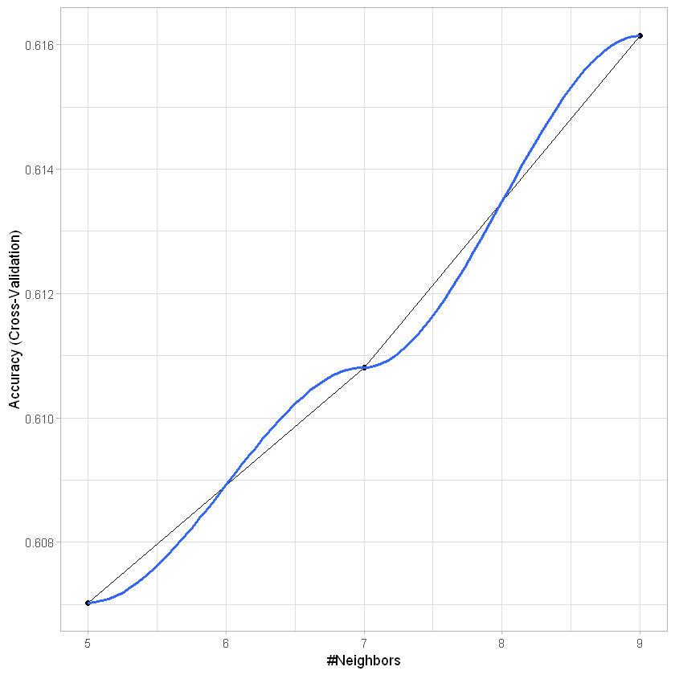

```r
#Implementing KNN

kNN3 <- train(shares~., data = traindata, method = "knn",
              maximize = TRUE,
              trControl = trainControl(method = "cv", number = 10),
              preProcess=c("center", "scale"))
ggplot(kNN3) + geom_line() + geom_smooth() + theme_light()

kNN3pred<-predict(kNN3,testdata,type="raw")
KNN3prob<-predict(kNN3,testdata,type="prob")

#predictedkNN3 <- predict(kNN3,newdata=testdata)
confusionMatrix(kNN3pred, testdata$shares)
```

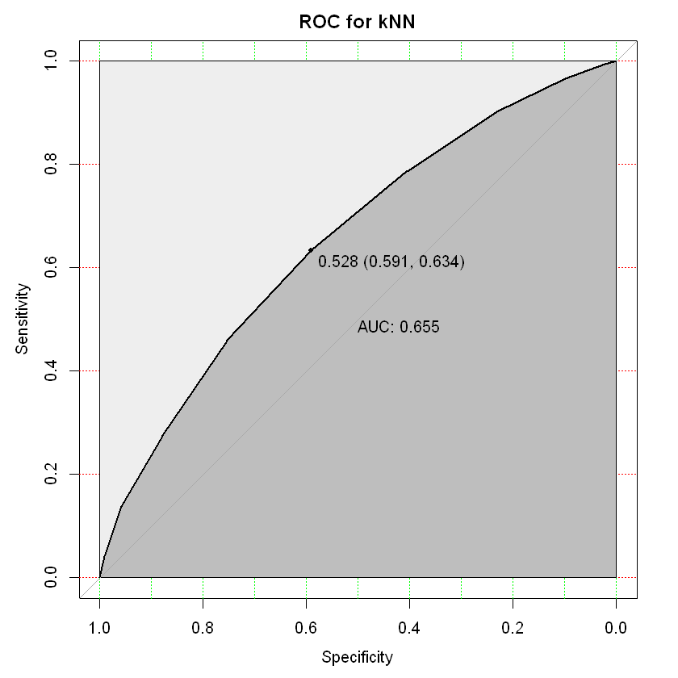

```r
#ROC kNN
newsKnnRoc <- roc(testdata$shares,KNN3prob[,2])
plot(newsKnnRoc, print.auc=TRUE, auc.polygon=TRUE, grid=c(0.1, 0.2),
     grid.col=c("green", "red"), max.auc.polygon=TRUE,
     auc.polygon.col="grey", print.thres=TRUE , main="ROC for kNN")
```